# Quality Control Report

This file contains the quality control information on the chips we used and choose not to use.

We were able to find limited amounts of human cell type specific data but they were shown to be of very poor quality. The sources and GEO IDs of these datasets can be found from this file

## Human Cell Type Data

```r
lapply(affies,function(x){
    mean(mm(x)>pm(x))
})
```

```
## $`Affymetrix U133 Plus 2.0`
## [1] 0.3319178
##
## $`Affymetrix U133_X3P`
## [1] 0.3612196
##
## $`Affymetrix U133A`
## [1] 0.4254485
```

Per chip ratio of MM>PM vs overall pm+mm intensity

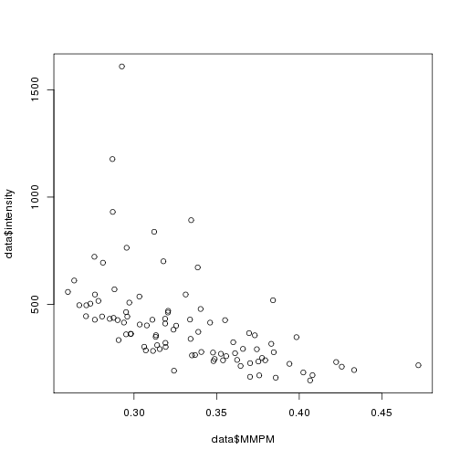

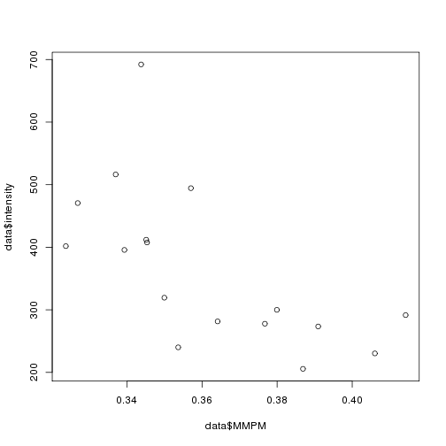

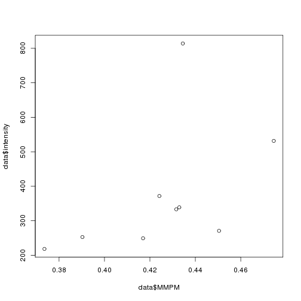

```
## $`Affymetrix U133 Plus 2.0`
## NULL
##
## $`Affymetrix U133_X3P`
## NULL
##
## $`Affymetrix U133A`
## NULL
```

```r
lapply(affies,function(x){
data = data.frame(MMPM = rep(0,len(x)), intensity = rep(0,len(x)))
for (i in 1:len(x)){
    data$MMPM[i] = mean(mm(x[,i]) > pm(x[,i]))
    data$intensity[i] = mean(pm(x[,i])+mm(x[,i]))
}
plot(data$MMPM,data$intensity)

}
)
```

A quite messy plots of density distributions. Note that there are multiple batches in the same chip

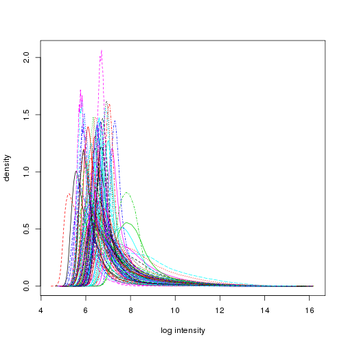

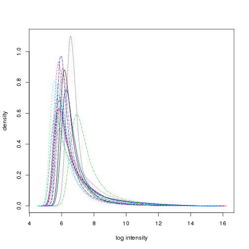

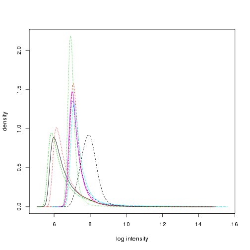

```r
ground = lapply(affies,hist)
```

And RNA degredation plots with mean slopes

```
## [1] 8.691982
```

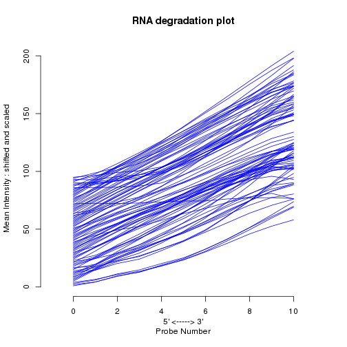

```
## [1] 6.182243
```

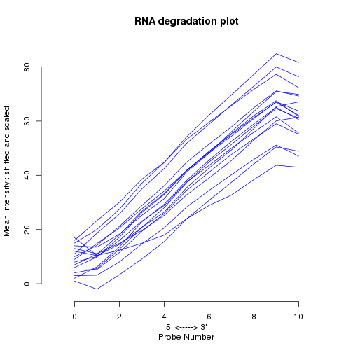

```
## [1] 3.976004
```

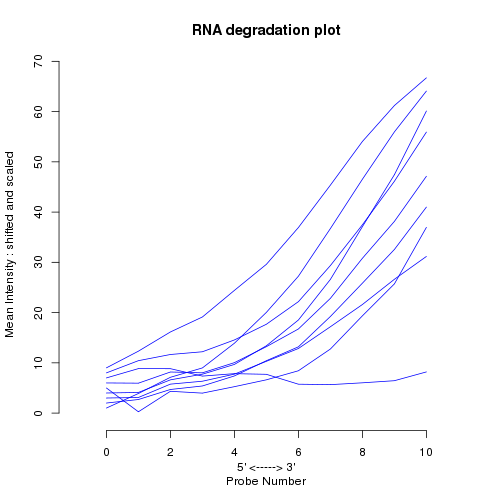

```r
ground = lapply(affies, function(x){
    deg = AffyRNAdeg(x)
    print(mean(deg$slope))
    plotAffyRNAdeg(deg)
})
```

In the first plot we notice a single sample with quite a low slope and decided to see the raw image file for that chip. Which turned out to be an unusually homogenous image

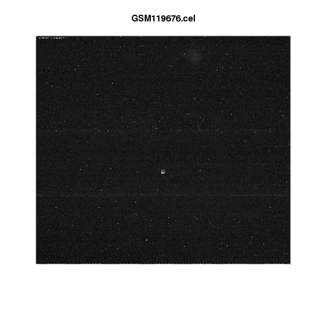

```r
deg = AffyRNAdeg(affies[[1]])
image(affies[[1]][,order(deg$slope)[1]])
```

A similar outlier also exists in the 3rd chip type

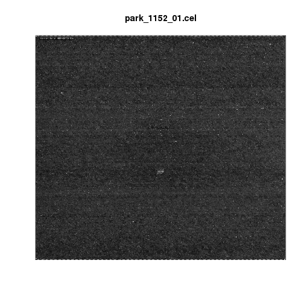

```r
deg = AffyRNAdeg(affies[[3]])
image(affies[[3]][,order(deg$slope)[1]])
```

## Mouse Cell Type

Lets proceed to our lovely mouse data, that has two platforms

```r
lapply(affies,function(x){
    mean(mm(x)>pm(x))
})
```

```
## $`Affymetrix 430 2.0`
## [1] 0.2769139
##
## $`Affymetrix MOE430A`
## [1] 0.2916909
```

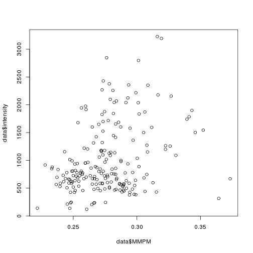

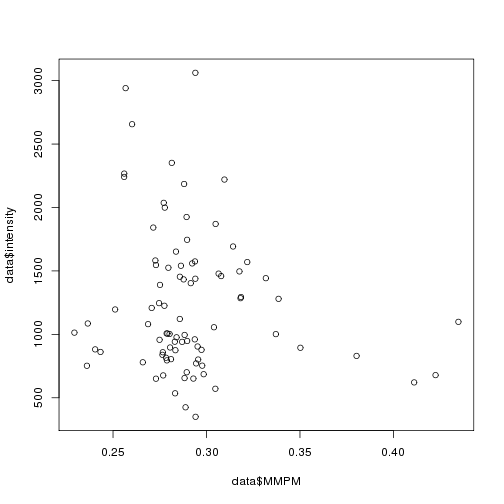

```
## $`Affymetrix 430 2.0`
## NULL
##
## $`Affymetrix MOE430A`
## NULL
```

```r
lapply(affies,function(x){
data = data.frame(MMPM = rep(0,len(x)), intensity = rep(0,len(x)))
for (i in 1:len(x)){
    data$MMPM[i] = mean(mm(x[,i]) > pm(x[,i]))
    data$intensity[i] = mean(pm(x[,i])+mm(x[,i]))
}
plot(data$MMPM,data$intensity)

}
)
```

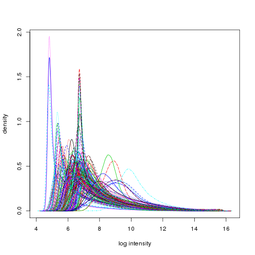

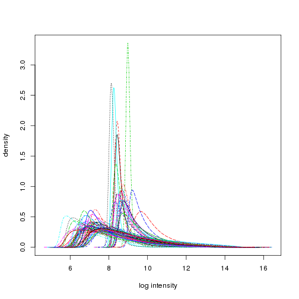

```r
ground = lapply(affies,hist)
```

```
## [1] 5.437618
```

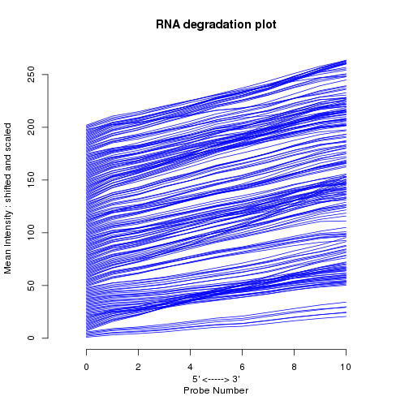

```
## [1] 4.84261
```

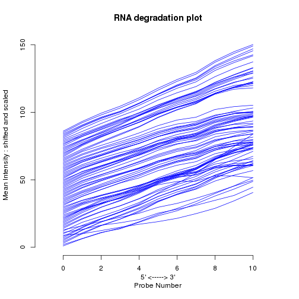

```r
ground = lapply(affies, function(x){
    deg = AffyRNAdeg(x)
    print(mean(deg$slope))
    plotAffyRNAdeg(deg)
})
```